# Project 1

Bryce Rowland

09/24/2018

## Dataset 1: Titanic Survivors

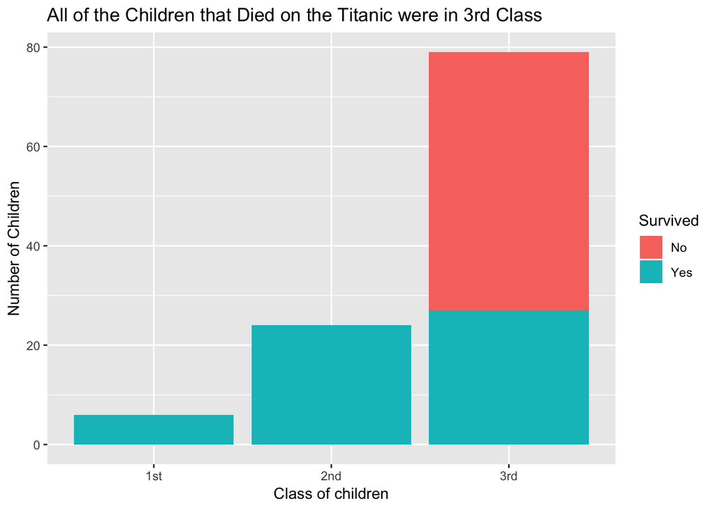

```r
child_deaths <- titanic %>%
  filter(Age == "Child" & Class != "Crew")

p <- ggplot(data = child_deaths, aes(x = Class,y = n)) +
  geom_bar(stat = "identity", aes(fill = Survived)) +
  labs(title = "All of the Children that Died on the Titanic were in 3rd Class",
       x = "Class of children",
       y = "Number of Children")
p
```

```r
num_children <- child_deaths %>% summarize(num_child = sum(n))

children_deaths <- child_deaths %>%
  group_by(Survived) %>%
  summarize(surv_totals = sum(n)) %>%
  filter(Survived == 'No') %>%
  select(surv_totals)

class_totals <- child_deaths %>%
  group_by(Class) %>%
  summarise(class_totals = sum(n))


survival_rates_by_class <- child_deaths %>%
  group_by(Class) %>%
  mutate(class_totals = sum(n)) %>%
  group_by(Class, Survived, class_totals) %>%
  summarise(surv_totals = sum(n)) %>%
  filter(Survived == "No") %>%
  mutate(death_rate = round((surv_totals/class_totals)*100,3),
         survival_rate = round(100-death_rate, 3))
```

## Datset 2: Swiss

```r
swiss$names <- rownames(swiss)
sw <- as.tibble(swiss) %>%
  mutate(Religiosity = if_else(Catholic <= 37.5, "Low Catholic", if_else(Catholic <= 62.5, "Medium Catholic", "Highly Catholic")))
```

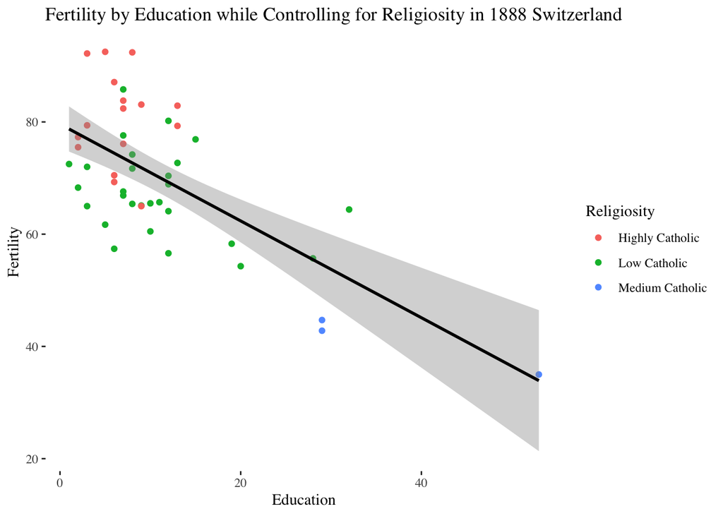

```r
p2 <- ggplot(data = sw, mapping = aes(x = Education, y = Fertility)) +
  geom_point(aes(colour = Religiosity)) +
  geom_smooth(method = "lm", colour = "black") +
  theme_tufte() +
  labs(legend = "Religiosity", title = "Fertility by Education while Controlling for Religiosity in 1888 Switzerland")
p2
```

```r
avgs <- sw %>%
  group_by(Religiosity) %>%
  summarise(avg_education = mean(Education), avg_fertility = mean(Fertility))
```

The data from this graph are from the `swiss` dataset. These data were collected during a time of demographic transition in Switzerland when their population was transitioning to lower levels of fertility which are characteristic of developed coutnries. I was interested in exploring how religion and education are assoicated with fertility. A categorical variable was defined for religiosity based on the percent of Catholics in a given province: Low (x <=37.5%), Medium(37.5% < x <= 62.5%), High (<62.5%). We see that there is a strong negative correlation between fertility and education - which is conducive with research on the topic. I was suprised to discover that the religiously mixed provinces were those with the lowest fertility rates and the highest rates of education. One could argue that on average, the highly Catholic provinces have higher fertility rates than provinces with low religiosity. The average fertility rate for provinces with High religiosity is 80.55, while the average fertility rate for provinces with medium religiosity is 40.8333